# ReCell Project Notebook

### Description

Buying and selling used smartphones used to be something that happened on a handful of online marketplace sites. But the used and refurbished phone market has grown considerably over the past decade, and a new IDC (International Data Corporation) forecast predicts that the used phone market would be worth $52.7bn by 2023 with a compound annual growth rate (CAGR) of 13.6% from 2018 to 2023. This growth can be attributed to an uptick in demand for used smartphones that offer considerable savings compared with new models.

Refurbished and used devices continue to provide cost-effective alternatives to both consumers and businesses that are looking to save money when purchasing a smartphone. There are plenty of other benefits associated with the used smartphone market. Used and refurbished devices can be sold with warranties and can also be insured with proof of purchase. Third-party vendors/platforms, such as Verizon, Amazon, etc., provide attractive offers to customers for refurbished smartphones. Maximizing the longevity of mobile phones through second-hand trade also reduces their environmental impact and helps in recycling and reducing waste. The impact of the COVID-19 outbreak may further boost the cheaper refurbished smartphone segment, as consumers cut back on discretionary spending and buy phones only for immediate needs.

### Objective

The rising potential of this comparatively under-the-radar market fuels the need for an ML-based solution to develop a dynamic pricing strategy for used and refurbished smartphones. ReCell, a startup aiming to tap the potential in this market, has hired you as a data scientist. They want you to analyze the data provided and build a linear regression model to predict the price of a used phone and identify factors that significantly influence it.

Data Description The data contains the different attributes of used/refurbished phones. The detailed data dictionary is given below.

Data Dictionary

- brand_name: Name of manufacturing brand
- os: OS on which the phone runs
- screen_size: Size of the screen in cm
- 4g: Whether 4G is available or not
- 5g: Whether 5G is available or not
- main_camera_mp: Resolution of the rear camera in megapixels
- selfie_camera_mp: Resolution of the front camera in megapixels
- int_memory: Amount of internal memory (ROM) in GB
- ram: Amount of RAM in GB
- battery: Energy capacity of the phone battery in mAh
- weight: Weight of the phone in grams
- release_year: Year when the phone model was released
- days_used: Number of days the used/refurbished phone has been used
- new_price: Price of a new phone of the same model in euros
- used_price: Price of the used/refurbished phone in euros

Dependent Variable: used_price

## Importing necessary libraries and data

```python
%reload_ext nb_black
# reading data
import pandas as pd
import numpy as np

# visualization
import matplotlib.pyplot as plt
import seaborn as sns

# modeling
from sklearn.model_selection import train_test_split
from sklearn.linear_model import LinearRegression
from sklearn.metrics import mean_absolute_error, mean_squared_error, r2_score

# linear model using statsmodel
import statsmodels.api as sm

# set random seed so same data is pulled in every time
np.random.seed(1)
```

```python
# import data
data = pd.read_csv("used_phone_data.csv")
print(f"There are {data.shape[0]} rows and {data.shape[1]} columns.")
```

```
There are 3571 rows and 15 columns.
```

## Data Overview

- Observations
- Sanity checks

```python
data.head()
```

|  | brand_name | os | screen_size | 4g | 5g | main_camera_mp | selfie_camera_mp | int_memory | ram | battery | weight | release_year | days_used | new_price | used_price |
| --- | --- | --- | --- | --- | --- | --- | --- | --- | --- | --- | --- | --- | --- | --- | --- |
| 0 | Honor | Android | 23.97 | yes | no | 13.0 | 5.0 | 64.0 | 3.0 | 3020.0 | 146.0 | 2020 | 127 | 111.62 | 86.96 |
| 1 | Honor | Android | 28.10 | yes | yes | 13.0 | 16.0 | 128.0 | 8.0 | 4300.0 | 213.0 | 2020 | 325 | 249.39 | 161.49 |
| 2 | Honor | Android | 24.29 | yes | yes | 13.0 | 8.0 | 128.0 | 8.0 | 4200.0 | 213.0 | 2020 | 162 | 359.47 | 268.55 |
| 3 | Honor | Android | 26.04 | yes | yes | 13.0 | 8.0 | 64.0 | 6.0 | 7250.0 | 480.0 | 2020 | 345 | 278.93 | 180.23 |
| 4 | Honor | Android | 15.72 | yes | no | 13.0 | 8.0 | 64.0 | 3.0 | 5000.0 | 185.0 | 2020 | 293 | 140.87 | 103.80 |

```python
# checking column data types and potential null values
data.info()
```

```
<class 'pandas.core.frame.DataFrame'>
RangeIndex: 3571 entries, 0 to 3570
Data columns (total 15 columns):
 #   Column            Non-Null Count  Dtype
---  ------            --------------  -----
 0   brand_name        3571 non-null   object
 1   os                3571 non-null   object
 2   screen_size       3571 non-null   float64
 3   4g                3571 non-null   object
 4   5g                3571 non-null   object
 5   main_camera_mp    3391 non-null   float64
 6   selfie_camera_mp  3569 non-null   float64
 7   int_memory        3561 non-null   float64
 8   ram               3561 non-null   float64
 9   battery           3565 non-null   float64
 10  weight            3564 non-null   float64
 11  release_year      3571 non-null   int64
 12  days_used         3571 non-null   int64
 13  new_price         3571 non-null   float64
 14  used_price        3571 non-null   float64
dtypes: float64(9), int64(2), object(4)
memory usage: 418.6+ KB
```

#### Thoughts:

- looks like there are a couple columns with null values: campera_mp,int_memory, ram, battery,weight. All of the internal camera qualitative values.
  - To process the null values using the column mean may work as there is not a large number of missing
- brand/os/4g/5g are object data types, most likely string text that will need to be converted if it is deemed useful for modeling
- all of the remaining columns are numbers; floats or integer format

```python
# statistical analysis including object columns
data.describe(include="all").T
```

|  | count | unique | top | freq | mean | std | min | 25% | 50% | 75% | max |
| --- | --- | --- | --- | --- | --- | --- | --- | --- | --- | --- | --- |
| brand_name | 3571 | 34 | Others | 509 | NaN | NaN | NaN | NaN | NaN | NaN | NaN |
| os | 3571 | 4 | Android | 3246 | NaN | NaN | NaN | NaN | NaN | NaN | NaN |
| screen_size | 3571 | NaN | NaN | NaN | 14.8039 | 5.15309 | 2.7 | 12.7 | 13.49 | 16.51 | 46.36 |
| 4g | 3571 | 2 | yes | 2359 | NaN | NaN | NaN | NaN | NaN | NaN | NaN |
| 5g | 3571 | 2 | no | 3419 | NaN | NaN | NaN | NaN | NaN | NaN | NaN |
| main_camera_mp | 3391 | NaN | NaN | NaN | 9.40045 | 4.8184 | 0.08 | 5 | 8 | 13 | 48 |
| selfie_camera_mp | 3569 | NaN | NaN | NaN | 6.54735 | 6.87936 | 0.3 | 2 | 5 | 8 | 32 |
| int_memory | 3561 | NaN | NaN | NaN | 54.5326 | 84.6962 | 0.005 | 16 | 32 | 64 | 1024 |
| ram | 3561 | NaN | NaN | NaN | 4.05696 | 1.39184 | 0.03 | 4 | 4 | 4 | 16 |
| battery | 3565 | NaN | NaN | NaN | 3067.23 | 1364.21 | 80 | 2100 | 3000 | 4000 | 12000 |
| weight | 3564 | NaN | NaN | NaN | 179.424 | 90.2809 | 23 | 140 | 159 | 184 | 950 |
| release_year | 3571 | NaN | NaN | NaN | 2015.96 | 2.29178 | 2013 | 2014 | 2016 | 2018 | 2020 |
| days_used | 3571 | NaN | NaN | NaN | 675.391 | 248.641 | 91 | 536 | 690 | 872 | 1094 |
| new_price | 3571 | NaN | NaN | NaN | 237.389 | 197.546 | 9.13 | 120.13 | 189.8 | 291.935 | 2560.2 |
| used_price | 3571 | NaN | NaN | NaN | 109.88 | 121.501 | 2.51 | 45.205 | 75.53 | 126 | 1916.54 |

- used phone prices range from 2.51 Euros to 1916.54 Euros
- new phone prices range from 9.13 Euros to 2560.2 Euros
- converting several columns to int64 data type and float data type will be useful
  - Convert to Int64 potentially: ram,main_camera_mp,selfie_camera_mp,int_memory,battery,weight,release_year, days_used
- combine 4g/5g into one column with categorical "yes/no"

```python
# null value count
data.isnull().sum()
```

```
brand_name            0
os                    0
screen_size           0
4g                    0
5g                    0
main_camera_mp      180
selfie_camera_mp      2
int_memory           10
ram                  10
battery               6
weight                7
release_year          0
days_used             0
new_price             0
used_price            0
dtype: int64
```

- most null values are in main_camera_mp column. We will have to replace the null values to assist with processing

## Exploratory Data Analysis (EDA)

- EDA is an important part of any project involving data.
- It is important to investigate and understand the data better before building a model with it.
- A few questions have been mentioned below which will help you approach the analysis in the right manner and generate insights from the data.
- A thorough analysis of the data, in addition to the questions mentioned below, should be done.

**Questions**:

1. What does the distribution of used phone prices look like?
2. What percentage of the used phone market is dominated by Android devices?
3. The amount of RAM is important for the smooth functioning of a phone. How does the amount of RAM vary with the brand?
4. A large battery often increases a phone's weight, making it feel uncomfortable in the hands. How does the weight vary for phones offering large batteries (more than 4500 mAh)?
5. Bigger screens are desirable for entertainment purposes as they offer a better viewing experience. How many phones are available across different brands with a screen size larger than 6 inches?
6. Budget phones nowadays offer great selfie cameras, allowing us to capture our favorite moments with loved ones. What is the distribution of budget phones offering greater than 8MP selfie cameras across brands?
7. Which attributes are highly correlated with the used phone price?

### Univariate Analysis

```python
# function to plot a boxplot and a histogram along the same scale.


def histogram_boxplot(data, feature, figsize=(12, 7), kde=False, bins=None):
    """
    Boxplot and histogram combined

    data: dataframe
    feature: dataframe column
    figsize: size of figure (default (12,7))
    kde: whether to the show density curve (default False)
    bins: number of bins for histogram (default None)
    """
    f2, (ax_box2, ax_hist2) = plt.subplots(
        nrows=2,  # Number of rows of the subplot grid= 2
        sharex=True,  # x-axis will be shared among all subplots
        gridspec_kw={"height_ratios": (0.25, 0.75)},
        figsize=figsize,
    )  # creating the 2 subplots
    sns.boxplot(
        data=data, x=feature, ax=ax_box2, showmeans=True, color="violet"
    )  # boxplot will be created and a star will indicate the mean value of the column
    sns.histplot(
        data=data, x=feature, kde=kde, ax=ax_hist2, bins=bins, palette="winter"
    ) if bins else sns.histplot(
        data=data, x=feature, kde=kde, ax=ax_hist2
    )  # For histogram
    ax_hist2.axvline(
        data[feature].mean(), color="green", linestyle="--"
    )  # Add mean to the histogram
    ax_hist2.axvline(
        data[feature].median(), color="black", linestyle="-"
    )  # Add median to the histogram
```

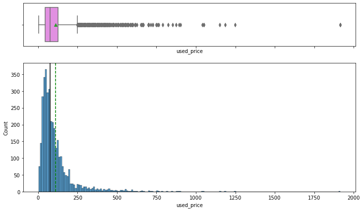

```python
# Dependent variable used_prices
histogram_boxplot(data, "used_price")
```

### Observations:

- very heavily right skewed
- Majority of the prices are below 250 Euros, however high outliers are pulling the data
- mean is around 109 Euros

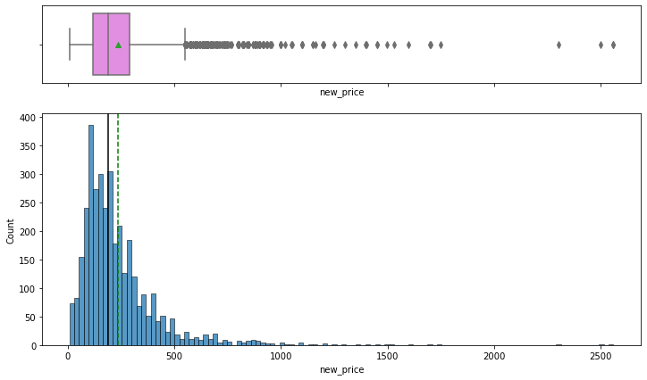

```python
# new prices
histogram_boxplot(data, "new_price")
```

### Observations:

- New prices are also heavily skewed to the right
- Majority of new prices also are close to mean, however there is a large range

### Bivariate Analysis

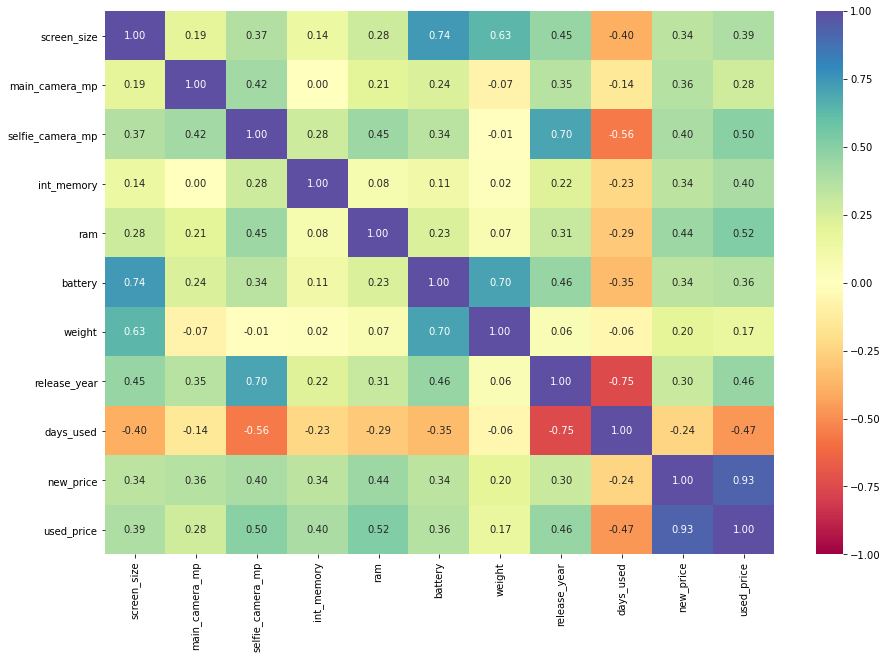

```python
# numeric column comparison
numeric_columns = data.select_dtypes(include=np.number).columns.tolist()
# correlation heatmap
plt.figure(figsize=(15, 10))
sns.heatmap(
    data[numeric_columns].corr(),
    annot=True,
    vmin=-1,
    vmax=1,
    fmt=".2f",
    cmap="Spectral",
)
plt.show()
```

### Observations:

- used price highest correlation is new price, which makes sense as you would want to be competitive with new prices and keep them in mind when setting used prices.
- days_used/release_year also affects used prices as a newish phone with lower days_used could lead to higher used_price
- battery and screen size have high correlation, and release_year and selfie_camer_mp as well which makes sense as selfies are rather new and so phones with increase mp on the selfie camera would be in more demand.

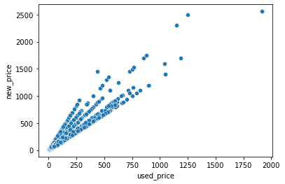

```python
sns.scatterplot(x="used_price", y="new_price", data=data)
```

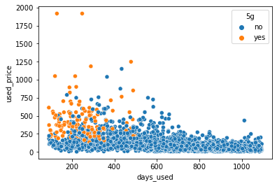

```python
sns.scatterplot(x="days_used", y="used_price", hue="5g", data=data)
```

- The older the phone the lower the price.
- Phones with 5G can get a higher price than phones without

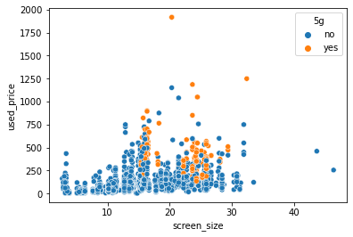

```python
sns.scatterplot(x="screen_size", y="used_price", hue="5g", data=data)
```

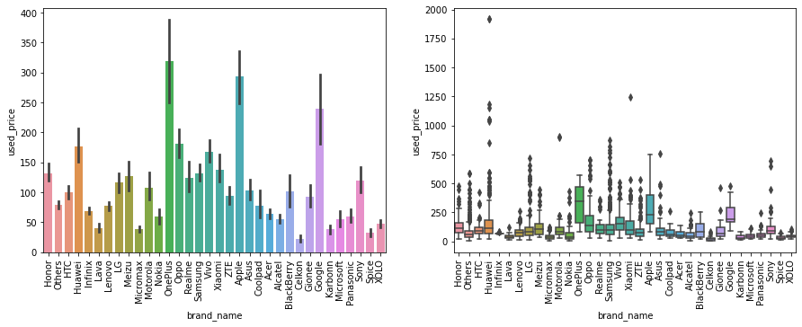

```python
plt.figure(figsize=(15, 5))

plt.subplot(1, 2, 1)
sns.barplot(data=data, y="used_price", x="brand_name")
plt.xticks(rotation=90)

plt.subplot(1, 2, 2)
sns.boxplot(data=data, y="used_price", x="brand_name")
plt.xticks(rotation=90)

plt.show()
```

- OnePlus, Apple and Google phones have the highest used prices

### Used Phones with Android Analysis

```python
# mean price across operating systems
data.groupby('os')['used_price'].mean()
```

```
os
Android    111.968598
Others      43.808366
Windows     65.083433
iOS        280.759286
Name: used_price, dtype: float64
```

- Android phones have the 2nd highest mean in Euros across the 4 main operating systems

```python
data.groupby("os")["used_price"].count()
```

```
os
Android    3246
Others      202
Windows      67
iOS          56
Name: used_price, dtype: int64
```

```python
# Percentage of the used phone market dominated by Android devices
andr = (3246 / 3571) * 100

print(
    "The percentage of Android phones in the used phone market is",
    round(andr, 2),
    "percent",
)
```

```
The percentage of Android phones in the used phone market is 90.9 percent
```

- Android phones make up a huge percent of the used phone market and also have the 2nd highest mean used_price

### How Does the amount of RAM vary with the brand?

```python
data.groupby('brand_name')['ram'].describe().T
```

| brand_name | Acer | Alcatel | Apple | Asus | BlackBerry | Celkon | Coolpad | Gionee | Google | HTC | ... | Others | Panasonic | Realme | Samsung | Sony | Spice | Vivo | XOLO | Xiaomi | ZTE |
| --- | --- | --- | --- | --- | --- | --- | --- | --- | --- | --- | --- | --- | --- | --- | --- | --- | --- | --- | --- | --- | --- |
| count | 51.000000 | 125.000000 | 59.000000 | 126.000000 | 22.000000 | 37.000000 | 22.000000 | 56.000000 | 15.000000 | 110.000000 | ... | 509.000000 | 47.0 | 41.000000 | 364.000000 | 88.000000 | 30.000000 | 117.000000 | 49.0 | 134.000000 | 141.000000 |
| mean | 3.901961 | 3.426000 | 4.000000 | 4.047619 | 3.829545 | 1.466216 | 3.954545 | 3.933036 | 4.533333 | 4.000000 | ... | 3.751041 | 4.0 | 4.195122 | 4.159341 | 4.068182 | 3.750000 | 4.756410 | 4.0 | 4.567164 | 4.023050 |
| std | 0.500196 | 1.247588 | 0.491304 | 0.591366 | 0.799503 | 1.779671 | 0.213201 | 0.501115 | 0.915475 | 0.331801 | ... | 1.057547 | 0.0 | 1.327018 | 1.366168 | 0.474534 | 0.951405 | 1.638196 | 0.0 | 1.533818 | 0.906278 |
| min | 1.000000 | 0.250000 | 2.000000 | 2.000000 | 0.250000 | 0.250000 | 3.000000 | 0.250000 | 4.000000 | 3.000000 | ... | 0.030000 | 4.0 | 2.000000 | 0.250000 | 4.000000 | 0.250000 | 0.500000 | 4.0 | 1.000000 | 0.250000 |
| 25% | 4.000000 | 4.000000 | 4.000000 | 4.000000 | 4.000000 | 0.250000 | 4.000000 | 4.000000 | 4.000000 | 4.000000 | ... | 4.000000 | 4.0 | 3.000000 | 4.000000 | 4.000000 | 4.000000 | 4.000000 | 4.0 | 4.000000 | 4.000000 |
| 50% | 4.000000 | 4.000000 | 4.000000 | 4.000000 | 4.000000 | 0.250000 | 4.000000 | 4.000000 | 4.000000 | 4.000000 | ... | 4.000000 | 4.0 | 4.000000 | 4.000000 | 4.000000 | 4.000000 | 4.000000 | 4.0 | 4.000000 | 4.000000 |
| 75% | 4.000000 | 4.000000 | 4.000000 | 4.000000 | 4.000000 | 4.000000 | 4.000000 | 4.000000 | 5.000000 | 4.000000 | ... | 4.000000 | 4.0 | 6.000000 | 4.000000 | 4.000000 | 4.000000 | 4.000000 | 4.0 | 4.000000 | 4.000000 |
| max | 4.000000 | 4.000000 | 6.000000 | 8.000000 | 4.000000 | 4.000000 | 4.000000 | 4.000000 | 6.000000 | 6.000000 | ... | 8.000000 | 4.0 | 6.000000 | 12.000000 | 8.000000 | 4.000000 | 8.000000 | 4.0 | 12.000000 | 8.000000 |

8 rows × 34 columns

```python
print(
    "Min:",
    data.ram.min(),
    "\tMean:",
    round(data.ram.mean(), 2),
    "\tMax:",
    data.ram.max(),
)
```

```
Min: 0.03 	Mean: 4.06 	Max: 16.0
```

- RAM amounts vary a lot across the brands ranging from 0.03GB to 16GB with an average of 4GB

```python
data.ram.value_counts()
```

```
4.00     2918
6.00      155
8.00      132
0.25      103
2.00       90
3.00       82
1.00       37
12.00      18
0.50       11
16.00       4
2.50        4
0.03        3
0.75        2
1.50        2
Name: ram, dtype: int64
```

- Most of the phone RAM is at 4GB

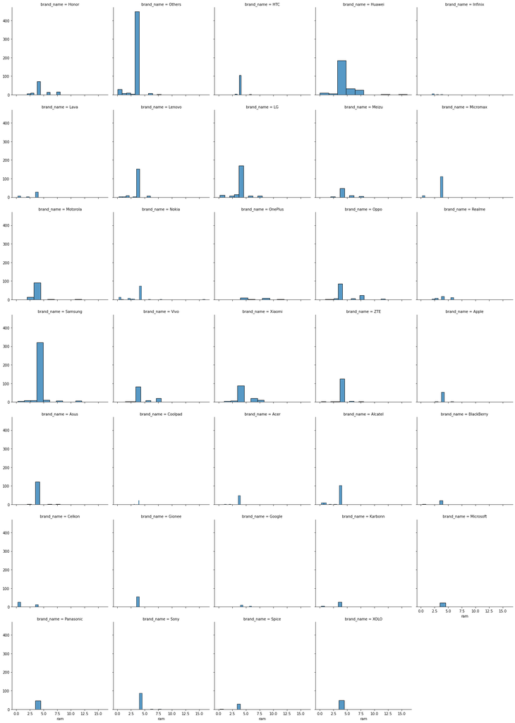

```python
g = sns.FacetGrid(data, col="brand_name", height=4, col_wrap=5)
g.map(sns.histplot, "ram")
```

### How does the weight vary for phones offering large batteries (more than 4500mAh)?

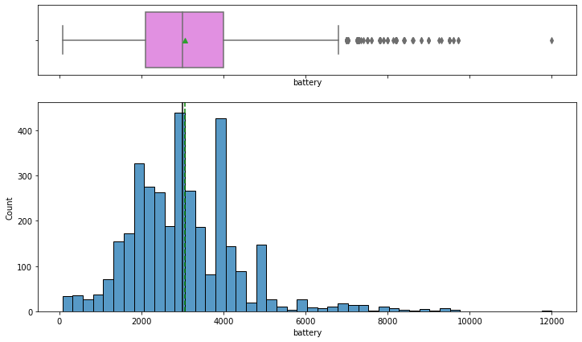

```python
histogram_boxplot(data, "battery")
```

```python
# Battery weight has extreme outliers otherwise it would be a fairly normal distribution
```

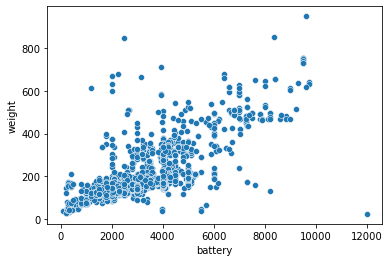

```python
sns.scatterplot(x="battery", y="weight", data=data)
```

- As battery power increases, so to does the phone weight

```python
# new data frame with batteries more than 4500 mAh
df_bat = data[data.battery > 4500]
df_bat.weight.describe()
```

```
count    346.000000
mean     330.718786
std      160.952677
min       23.000000
25%      198.000000
50%      299.000000
75%      467.000000
max      950.000000
Name: weight, dtype: float64
```

- The weight for batteries over 4500 mAh varies from 23g to 950g with an average of 330g. The standard deviation is rather large meaning there are extreme outliers

### How many phones are available across different brands with a screen size larger than 6 inches?

```python
# 6 inches is around 15 cm.  Units in data is in cm.
df_screen = data[data.screen_size > 15]
print(
    "There are",
    df_screen.brand_name.count(),
    "phones available with a screen size larger than 6 inches.",
)
```

```
There are 1370 phones available with a screen size larger than 6 inches.
```

```python
df_screen.brand_name.value_counts()
```

```
Huawei        167
Samsung       140
Others        136
Xiaomi         89
Vivo           88
Honor          88
Lenovo         79
Oppo           78
LG             72
Asus           54
Motorola       45
Realme         41
Alcatel        36
Nokia          32
ZTE            30
Meizu          29
Sony           25
Apple          24
Acer           20
OnePlus        16
HTC            15
Micromax       15
Gionee         12
Infinix        10
Google          7
XOLO            5
Coolpad         3
Panasonic       3
Lava            2
Celkon          2
Karbonn         2
BlackBerry      2
Spice           2
Microsoft       1
Name: brand_name, dtype: int64
```

```python
def labeled_barplot(data, feature, perc=False, n=None):
    """
    Barplot with percentage at the top

    data: dataframe
    feature: dataframe column
    perc: whether to display percentages instead of count (default is False)
    n: displays the top n category levels (default is None, i.e., display all levels)
    """

    total = len(data[feature])  # length of the column
    count = data[feature].nunique()
    if n is None:
        plt.figure(figsize=(count + 1, 5))
    else:
        plt.figure(figsize=(n + 1, 5))

    plt.xticks(rotation=90, fontsize=15)
    ax = sns.countplot(
        data=data,
        x=feature,
        palette="Paired",
        order=data[feature].value_counts().index[:n].sort_values(),
    )

    for p in ax.patches:
        if perc == True:
            label = "{:.1f}%".format(
                100 * p.get_height() / total
            )  # percentage of each class of the category
        else:
            label = p.get_height()  # count of each level of the category

        x = p.get_x() + p.get_width() / 2  # width of the plot
        y = p.get_height()  # height of the plot

        ax.annotate(
            label,
            (x, y),
            ha="center",
            va="center",
            size=12,
            xytext=(0, 5),
            textcoords="offset points",
        )  # annotate the percentage

    plt.show()  # show the plot
```

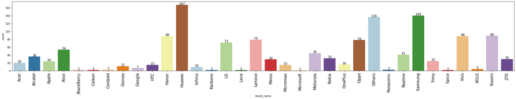

```python
labeled_barplot(df_screen, "brand_name")
```

### What is the distribution of budget phones offering greater than 8MP selfie cameras across brands?

- "Budget" will be defined as used phone prices less than the mean

```python
print("The mean used phone price is:", round(data.used_price.mean(), 0), "Euros")
print("Budget phones are used phones less than the mean")
```

```
The mean used phone price is: 110.0 Euros
Budget phones are used phones less than the mean
```

```python
# filter by price and camera MP
camera = data[(data.used_price <= 110) & (data.selfie_camera_mp > 8)]
camera.groupby("brand_name")["used_price"].count()
```

```
brand_name
Acer          1
Asus          3
Coolpad       1
Gionee        1
HTC           4
Honor         9
Huawei       11
Infinix       4
LG            4
Lenovo        6
Meizu         5
Micromax      1
Motorola      6
Nokia         3
Oppo         11
Others        6
Panasonic     1
Realme       13
Samsung       9
Sony          9
Vivo          9
Xiaomi       15
ZTE           9
Name: used_price, dtype: int64
```

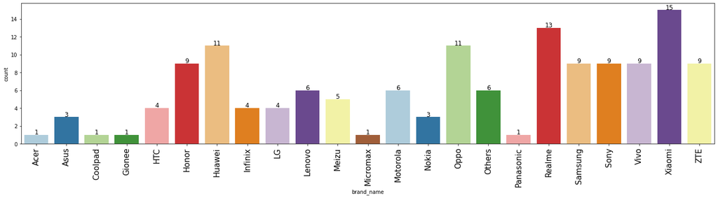

```python
labeled_barplot(camera, "brand_name")
```

- For "budget" phones less than 110 Euros and selfie cameras greater than 8MP, Xiaomi has 15 phones for sale

### Which attributes are highly correlated with the used phone price?

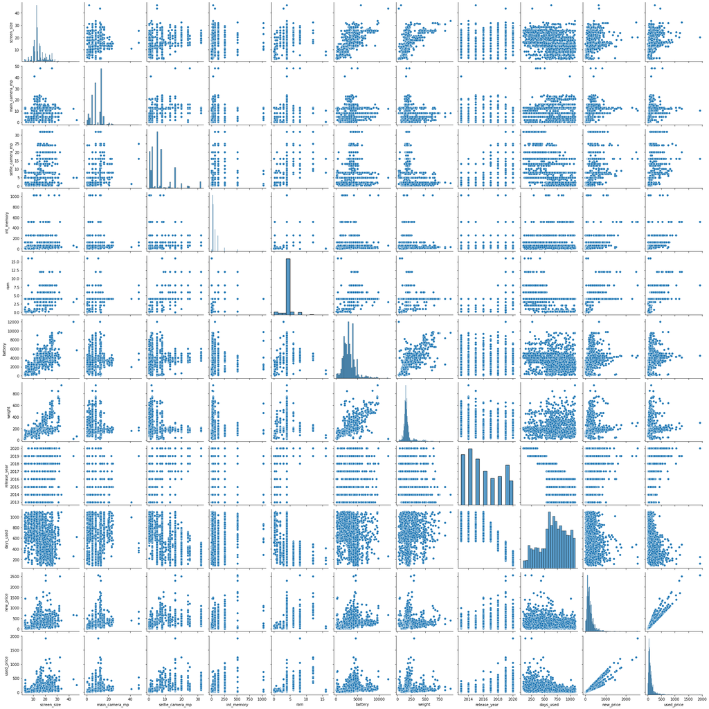

```python
# Already looked at the heatmap, so we will show scatter plots
sns.pairplot(data)
```

- The highest correlation to used_price is new_price with smaller correlations showing with release_year.
- This makes sense as a seller of used phones would want to be competitive and still make a profit.

## Data Preprocessing

- Missing value treatment
- Feature engineering (if needed)
- Outlier detection and treatment (if needed)
- Preparing data for modeling
- Any other preprocessing steps (if needed)

```python
# null values pre adjusted
data.isnull().sum()
```

```
brand_name            0
os                    0
screen_size           0
4g                    0
5g                    0
main_camera_mp      180
selfie_camera_mp      2
int_memory           10
ram                  10
battery               6
weight                7
release_year          0
days_used             0
new_price             0
used_price            0
dtype: int64
```

```python
# make a copy just in case :)
data2 = data.copy()
```

```python
# replace null values with column median
medianFiller = lambda x: x.fillna(x.median())
numeric_columns = data2.select_dtypes(include=np.number).columns.tolist()
data2[numeric_columns] = data2[numeric_columns].apply(medianFiller, axis=0)
```

```python
# double check null values
data2.isnull().sum()
```

```
brand_name          0
os                  0
screen_size         0
4g                  0
5g                  0
main_camera_mp      0
selfie_camera_mp    0
int_memory          0
ram                 0
battery             0
weight              0
release_year        0
days_used           0
new_price           0
used_price          0
dtype: int64
```

```python
# no missing values now
```

## EDA

- It is a good idea to explore the data once again after manipulating it.

```python
data2.describe().T
```

|  | count | mean | std | min | 25% | 50% | 75% | max |
| --- | --- | --- | --- | --- | --- | --- | --- | --- |
| screen_size | 3571.0 | 14.803892 | 5.153092 | 2.700 | 12.700 | 13.49 | 16.510 | 46.36 |
| main_camera_mp | 3571.0 | 9.329863 | 4.705341 | 0.080 | 5.000 | 8.00 | 13.000 | 48.00 |
| selfie_camera_mp | 3571.0 | 6.546486 | 6.877529 | 0.300 | 2.000 | 5.00 | 8.000 | 32.00 |
| int_memory | 3571.0 | 54.469509 | 84.585924 | 0.005 | 16.000 | 32.00 | 64.000 | 1024.00 |
| ram | 3571.0 | 4.056802 | 1.389897 | 0.030 | 4.000 | 4.00 | 4.000 | 16.00 |
| battery | 3571.0 | 3067.112714 | 1363.062572 | 80.000 | 2100.000 | 3000.00 | 4000.000 | 12000.00 |
| weight | 3571.0 | 179.384248 | 90.196828 | 23.000 | 140.000 | 159.00 | 184.000 | 950.00 |
| release_year | 3571.0 | 2015.964996 | 2.291784 | 2013.000 | 2014.000 | 2016.00 | 2018.000 | 2020.00 |
| days_used | 3571.0 | 675.391487 | 248.640972 | 91.000 | 536.000 | 690.00 | 872.000 | 1094.00 |
| new_price | 3571.0 | 237.389037 | 197.545581 | 9.130 | 120.130 | 189.80 | 291.935 | 2560.20 |
| used_price | 3571.0 | 109.880277 | 121.501226 | 2.510 | 45.205 | 75.53 | 126.000 | 1916.54 |

```python
# Let's look at the statistical summary of the data
pd.set_option(
    "display.float_format", lambda x: "%.3f" % x
)  # to display numbers rounded off to 3 decimal places

data2.describe(include="all").T
```

|  | count | unique | top | freq | mean | std | min | 25% | 50% | 75% | max |
| --- | --- | --- | --- | --- | --- | --- | --- | --- | --- | --- | --- |
| brand_name | 3571 | 34 | Others | 509 | NaN | NaN | NaN | NaN | NaN | NaN | NaN |
| os | 3571 | 4 | Android | 3246 | NaN | NaN | NaN | NaN | NaN | NaN | NaN |
| screen_size | 3571.000 | NaN | NaN | NaN | 14.804 | 5.153 | 2.700 | 12.700 | 13.490 | 16.510 | 46.360 |
| 4g | 3571 | 2 | yes | 2359 | NaN | NaN | NaN | NaN | NaN | NaN | NaN |
| 5g | 3571 | 2 | no | 3419 | NaN | NaN | NaN | NaN | NaN | NaN | NaN |
| main_camera_mp | 3571.000 | NaN | NaN | NaN | 9.330 | 4.705 | 0.080 | 5.000 | 8.000 | 13.000 | 48.000 |
| selfie_camera_mp | 3571.000 | NaN | NaN | NaN | 6.546 | 6.878 | 0.300 | 2.000 | 5.000 | 8.000 | 32.000 |
| int_memory | 3571.000 | NaN | NaN | NaN | 54.470 | 84.586 | 0.005 | 16.000 | 32.000 | 64.000 | 1024.000 |
| ram | 3571.000 | NaN | NaN | NaN | 4.057 | 1.390 | 0.030 | 4.000 | 4.000 | 4.000 | 16.000 |
| battery | 3571.000 | NaN | NaN | NaN | 3067.113 | 1363.063 | 80.000 | 2100.000 | 3000.000 | 4000.000 | 12000.000 |
| weight | 3571.000 | NaN | NaN | NaN | 179.384 | 90.197 | 23.000 | 140.000 | 159.000 | 184.000 | 950.000 |
| release_year | 3571.000 | NaN | NaN | NaN | 2015.965 | 2.292 | 2013.000 | 2014.000 | 2016.000 | 2018.000 | 2020.000 |
| days_used | 3571.000 | NaN | NaN | NaN | 675.391 | 248.641 | 91.000 | 536.000 | 690.000 | 872.000 | 1094.000 |
| new_price | 3571.000 | NaN | NaN | NaN | 237.389 | 197.546 | 9.130 | 120.130 | 189.800 | 291.935 | 2560.200 |
| used_price | 3571.000 | NaN | NaN | NaN | 109.880 | 121.501 | 2.510 | 45.205 | 75.530 | 126.000 | 1916.540 |

```python
# compare before and after adjusting null values
data2.describe() - data.describe()
```

|  | screen_size | main_camera_mp | selfie_camera_mp | int_memory | ram | battery | weight | release_year | days_used | new_price | used_price |
| --- | --- | --- | --- | --- | --- | --- | --- | --- | --- | --- | --- |
| count | 0.000 | 180.000 | 2.000 | 10.000 | 10.000 | 6.000 | 7.000 | 0.000 | 0.000 | 0.000 | 0.000 |
| mean | 0.000 | -0.071 | -0.001 | -0.063 | -0.000 | -0.113 | -0.040 | 0.000 | 0.000 | 0.000 | 0.000 |
| std | 0.000 | -0.113 | -0.002 | -0.110 | -0.002 | -1.144 | -0.084 | 0.000 | 0.000 | 0.000 | 0.000 |
| min | 0.000 | 0.000 | 0.000 | 0.000 | 0.000 | 0.000 | 0.000 | 0.000 | 0.000 | 0.000 | 0.000 |
| 25% | 0.000 | 0.000 | 0.000 | 0.000 | 0.000 | 0.000 | 0.000 | 0.000 | 0.000 | 0.000 | 0.000 |
| 50% | 0.000 | 0.000 | 0.000 | 0.000 | 0.000 | 0.000 | 0.000 | 0.000 | 0.000 | 0.000 | 0.000 |
| 75% | 0.000 | 0.000 | 0.000 | 0.000 | 0.000 | 0.000 | 0.000 | 0.000 | 0.000 | 0.000 | 0.000 |
| max | 0.000 | 0.000 | 0.000 | 0.000 | 0.000 | 0.000 | 0.000 | 0.000 | 0.000 | 0.000 | 0.000 |

```python
data2.info()
```

```
<class 'pandas.core.frame.DataFrame'>
RangeIndex: 3571 entries, 0 to 3570
Data columns (total 15 columns):
 #   Column            Non-Null Count  Dtype
---  ------            --------------  -----
 0   brand_name        3571 non-null   object
 1   os                3571 non-null   object
 2   screen_size       3571 non-null   float64
 3   4g                3571 non-null   object
 4   5g                3571 non-null   object
 5   main_camera_mp    3571 non-null   float64
 6   selfie_camera_mp  3571 non-null   float64
 7   int_memory        3571 non-null   float64
 8   ram               3571 non-null   float64
 9   battery           3571 non-null   float64
 10  weight            3571 non-null   float64
 11  release_year      3571 non-null   int64
 12  days_used         3571 non-null   int64
 13  new_price         3571 non-null   float64
 14  used_price        3571 non-null   float64
dtypes: float64(9), int64(2), object(4)
memory usage: 418.6+ KB
```

```python
# main_camera_mp had the most null values.  Compare before and after
data2.main_camera_mp.describe() - data.main_camera_mp.describe()
```

```
count   180.000
mean     -0.071
std      -0.113
min       0.000
25%       0.000
50%       0.000
75%       0.000
max       0.000
Name: main_camera_mp, dtype: float64
```

```python
# looks like adjusting the null values only slightly adjust the mean and standard deviation which is good.
```

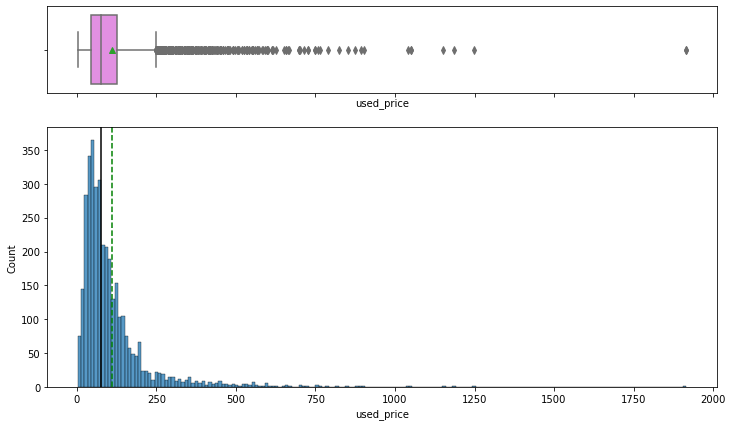

```python
histogram_boxplot(data2, "used_price")
```

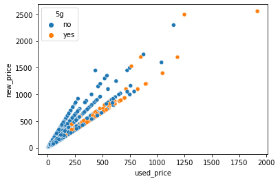

```python
# new_price vs used_price and whether it is 5g
sns.scatterplot(y="new_price", x="used_price", hue="5g", data=data2)
```

- 5g phones increase the used_price
- as the new_price increases so to does the used_price

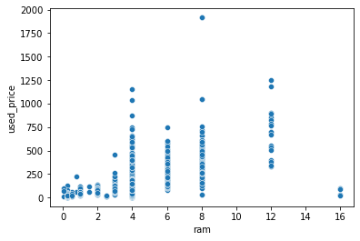

```python
# RAM impact on phone prices
sns.scatterplot(y="used_price", x="ram", data=data2)
```

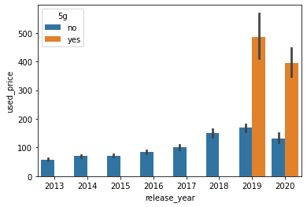

```python
# used_price vs release_year by 5g
sns.barplot(y="used_price", x="release_year", hue="5g", data=data2)
```

- The newer the phone the more expensive the price
- Only 2019 and 2020 phones have 5G, which increases the price even more

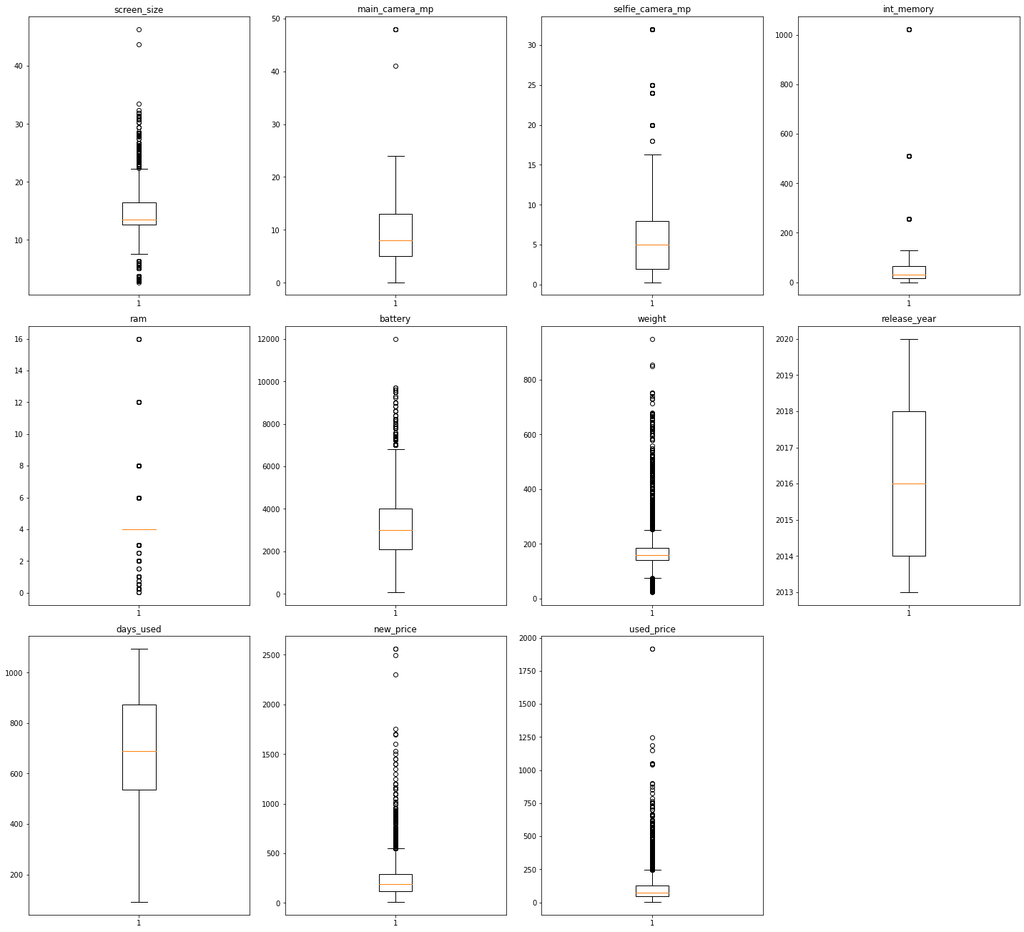

```python
numeric_columns2 = data2.select_dtypes(include=np.number).columns.tolist()
# let's plot the boxplots of all columns to check for outliers
plt.figure(figsize=(20, 30))

for i, variable in enumerate(numeric_columns2):
    plt.subplot(5, 4, i + 1)
    plt.boxplot(data2[variable], whis=1.5)
    plt.tight_layout()
    plt.title(variable)

plt.show()
```

```python
def treat_outliers(df, col):
    """
    treats outliers in a variable
    col: str, name of the numerical variable
    df: dataframe
    col: name of the column
    """
    Q1 = data2[col].quantile(0.25)  # 25th quantile
    Q3 = data2[col].quantile(0.75)  # 75th quantile
    IQR = Q3 - Q1
    Lower_Whisker = Q1 - 1.5 * IQR
    Upper_Whisker = Q3 + 1.5 * IQR

    # all the values smaller than Lower_Whisker will be assigned the value of Lower_Whisker
    # all the values greater than Upper_Whisker will be assigned the value of Upper_Whisker
    data2[col] = np.clip(data2[col], Lower_Whisker, Upper_Whisker)

    return df


def treat_outliers_all(df, col_list):
    """
    treat outlier in all numerical variables
    col_list: list of numerical variables
    df: data frame
    """
    for c in col_list:
        df = treat_outliers(df, c)

    return df
```

```python
numerical_col2 = data2.select_dtypes(include=np.number).columns.tolist()
df = treat_outliers_all(data2, numerical_col2)
```

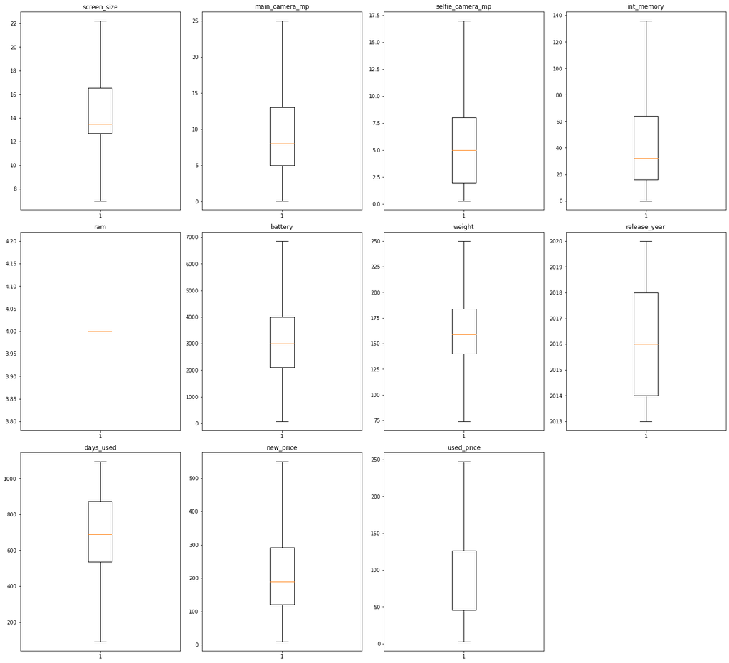

```python
# let's look at the boxplots to see if the outliers have been treated or not
plt.figure(figsize=(20, 30))

for i, variable in enumerate(numeric_columns2):
    plt.subplot(5, 4, i + 1)
    plt.boxplot(data2[variable], whis=1.5)
    plt.tight_layout()
    plt.title(variable)

plt.show()
```

## Building a Linear Regression model

1. We want to predict the used phone price.
2. Before we proceed to build a model, we'll have to encode categorical features.
3. We'll split the data into train and test to be able to evaluate the model that we build on the train data.
4. We will build a Linear Regression model using the train data and then check it's performance.
5. Dropping RAM

```python
# defining the x and y variable
x = data2.drop(["used_price", "ram"], axis=1)
y = data2["used_price"]

print(x.head())

print(y.head())
```

```
  brand_name       os  screen_size   4g   5g  main_camera_mp  \
0      Honor  Android       22.225  yes   no          13.000
1      Honor  Android       22.225  yes  yes          13.000
2      Honor  Android       22.225  yes  yes          13.000
3      Honor  Android       22.225  yes  yes          13.000
4      Honor  Android       15.720  yes   no          13.000

   selfie_camera_mp  int_memory  battery  weight  release_year  days_used  \
0             5.000      64.000 3020.000 146.000          2020        127
1            16.000     128.000 4300.000 213.000          2020        325
2             8.000     128.000 4200.000 213.000          2020        162
3             8.000      64.000 6850.000 250.000          2020        345
4             8.000      64.000 5000.000 185.000          2020        293

   new_price
0    111.620
1    249.390
2    359.470
3    278.930
4    140.870
0    86.960
1   161.490
2   247.192
3   180.230
4   103.800
Name: used_price, dtype: float64
```

```python
# categorical splitting
x2 = pd.get_dummies(
    x,
    columns=x.select_dtypes(include=["object", "category"]).columns.tolist(),
    drop_first=True,
)
x2.head()
```

|  | screen_size | main_camera_mp | selfie_camera_mp | int_memory | battery | weight | release_year | days_used | new_price | brand_name_Alcatel | ... | brand_name_Spice | brand_name_Vivo | brand_name_XOLO | brand_name_Xiaomi | brand_name_ZTE | os_Others | os_Windows | os_iOS | 4g_yes | 5g_yes |
| --- | --- | --- | --- | --- | --- | --- | --- | --- | --- | --- | --- | --- | --- | --- | --- | --- | --- | --- | --- | --- | --- |
| 0 | 22.225 | 13.000 | 5.000 | 64.000 | 3020.000 | 146.000 | 2020 | 127 | 111.620 | 0 | ... | 0 | 0 | 0 | 0 | 0 | 0 | 0 | 0 | 1 | 0 |
| 1 | 22.225 | 13.000 | 16.000 | 128.000 | 4300.000 | 213.000 | 2020 | 325 | 249.390 | 0 | ... | 0 | 0 | 0 | 0 | 0 | 0 | 0 | 0 | 1 | 1 |
| 2 | 22.225 | 13.000 | 8.000 | 128.000 | 4200.000 | 213.000 | 2020 | 162 | 359.470 | 0 | ... | 0 | 0 | 0 | 0 | 0 | 0 | 0 | 0 | 1 | 1 |
| 3 | 22.225 | 13.000 | 8.000 | 64.000 | 6850.000 | 250.000 | 2020 | 345 | 278.930 | 0 | ... | 0 | 0 | 0 | 0 | 0 | 0 | 0 | 0 | 1 | 1 |
| 4 | 15.720 | 13.000 | 8.000 | 64.000 | 5000.000 | 185.000 | 2020 | 293 | 140.870 | 0 | ... | 0 | 0 | 0 | 0 | 0 | 0 | 0 | 0 | 1 | 0 |

5 rows × 47 columns

```python
# preparing train data in 70:30
x_train, x_test, y_train, y_test = train_test_split(
    x2, y, test_size=0.3, random_state=42
)
```

```python
print("Number of rows in train data =", x_train.shape[0])
print("Number of rows in test data =", x_test.shape[0])
```

```
Number of rows in train data = 2499
Number of rows in test data = 1072
```

```python
# now we fit the model to the train data which is 70% of the whole data
from sklearn.linear_model import LinearRegression

linearregression = LinearRegression()
linearregression.fit(x_train, y_train)
```

```
LinearRegression()
```

```python
# check the coefficients and intercepts of the train data
coef = pd.DataFrame(
    np.append(linearregression.coef_, linearregression.intercept_),
    index=x_train.columns.tolist() + ["Intercept"],
    columns=["Coefficients"],
)
coef
```

|  | Coefficients |
| --- | --- |
| screen_size | 0.208 |
| main_camera_mp | -0.274 |
| selfie_camera_mp | 0.838 |
| int_memory | 0.086 |
| battery | 0.000 |
| weight | -0.012 |
| release_year | -0.246 |
| days_used | -0.085 |
| new_price | 0.384 |
| brand_name_Alcatel | 0.180 |
| brand_name_Apple | 23.243 |
| brand_name_Asus | 0.589 |
| brand_name_BlackBerry | 6.697 |
| brand_name_Celkon | -0.716 |
| brand_name_Coolpad | 6.615 |
| brand_name_Gionee | -5.288 |
| brand_name_Google | 12.229 |
| brand_name_HTC | -0.640 |
| brand_name_Honor | 2.072 |
| brand_name_Huawei | 0.972 |
| brand_name_Infinix | -14.903 |
| brand_name_Karbonn | -1.357 |
| brand_name_LG | 1.745 |
| brand_name_Lava | -1.321 |
| brand_name_Lenovo | -1.720 |
| brand_name_Meizu | -0.661 |
| brand_name_Micromax | 1.199 |
| brand_name_Microsoft | -3.479 |
| brand_name_Motorola | -0.773 |
| brand_name_Nokia | -7.483 |
| brand_name_OnePlus | -16.876 |
| brand_name_Oppo | -2.628 |
| brand_name_Others | 0.419 |
| brand_name_Panasonic | 1.332 |
| brand_name_Realme | -2.679 |
| brand_name_Samsung | 0.578 |
| brand_name_Sony | 1.032 |
| brand_name_Spice | 1.772 |
| brand_name_Vivo | 0.916 |
| brand_name_XOLO | 2.837 |
| brand_name_Xiaomi | -1.318 |
| brand_name_ZTE | -0.504 |
| os_Others | -4.003 |
| os_Windows | 2.529 |
| os_iOS | -15.808 |
| 4g_yes | -2.884 |
| 5g_yes | 2.123 |
| Intercept | 557.484 |

## Model performance evaluation

**Let's check the performance of the model using different metrics.**

- We will be using metric functions defined in sklearn for RMSE, MAE, and $R^2$.
- We will define a function to calculate MAPE and adjusted $R^2$.
  - The mean absolute percentage error (MAPE) measures the accuracy of predictions as a percentage, and can be calculated as the average absolute percent error for each predicted value minus actual values divided by actual values. It works best if there are no extreme values in the data and none of the actual values are 0.
- We will create a function which will print out all the above metrics in one go.

```python
# function to compute adjusted R-squared
def adj_r2_score(predictors, targets, predictions):
    r2 = r2_score(targets, predictions)
    n = predictors.shape[0]
    k = predictors.shape[1]
    return 1 - ((1 - r2) * (n - 1) / (n - k - 1))


# function to compute MAPE
def mape_score(targets, predictions):
    return np.mean(np.abs(targets - predictions) / targets) * 100


# function to compute different metrics to check performance of a regression model
def model_performance_regression(model, predictors, target):
    """
    Function to compute different metrics to check regression model performance

    model: regressor
    predictors: independent variables
    target: dependent variable
    """

    # predicting using the independent variables
    pred = model.predict(predictors)

    r2 = r2_score(target, pred)  # to compute R-squared
    adjr2 = adj_r2_score(predictors, target, pred)  # to compute adjusted R-squared
    rmse = np.sqrt(mean_squared_error(target, pred))  # to compute RMSE
    mae = mean_absolute_error(target, pred)  # to compute MAE
    mape = mape_score(target, pred)  # to compute MAPE

    # creating a dataframe of metrics
    df_perf = pd.DataFrame(
        {
            "RMSE": rmse,
            "MAE": mae,
            "R-squared": r2,
            "Adj. R-squared": adjr2,
            "MAPE": mape,
        },
        index=[0],
    )

    return df_perf
```

```python
# checking model performance on train set (seen 70% data)
print("Training Performance\n")
linearregression_train_perf = model_performance_regression(
    linearregression, x_train, y_train
)
linearregression_train_perf
```

```
Training Performance
```

|  | RMSE | MAE | R-squared | Adj. R-squared | MAPE |
| --- | --- | --- | --- | --- | --- |
| 0 | 13.960 | 10.222 | 0.955 | 0.954 | 18.489 |

```python
# Test performance
print("Test Performance\n")
linearregression_train_perf = model_performance_regression(
    linearregression, x_test, y_test
)
linearregression_train_perf
```

```
Test Performance
```

|  | RMSE | MAE | R-squared | Adj. R-squared | MAPE |
| --- | --- | --- | --- | --- | --- |
| 0 | 13.745 | 10.171 | 0.957 | 0.955 | 16.418 |

### Observations

- Our model explains 95% of the variation in the train data.
- RMSE and MAE on the train and test sets are close, which means that the model is not overfitting
- Our model predicts used_price within a mean error of 13 Euros

```python
# stats model
x_train1 = sm.add_constant(x_train)
# adding constant to the test data
x_test1 = sm.add_constant(x_test)

olsmod0 = sm.OLS(y_train, x_train1).fit()
print(olsmod0.summary())
```

```
                            OLS Regression Results
==============================================================================
Dep. Variable:             used_price   R-squared:                       0.955
Model:                            OLS   Adj. R-squared:                  0.954
Method:                 Least Squares   F-statistic:                     1110.
Date:                Tue, 17 Aug 2021   Prob (F-statistic):               0.00
Time:                        09:52:42   Log-Likelihood:                -10134.
No. Observations:                2499   AIC:                         2.036e+04
Df Residuals:                    2451   BIC:                         2.064e+04
Df Model:                          47
Covariance Type:            nonrobust
=========================================================================================
                            coef    std err          t      P>|t|      [0.025      0.975]
-----------------------------------------------------------------------------------------
const                   557.4842    553.062      1.008      0.314    -527.032    1642.000
screen_size               0.2077      0.127      1.633      0.103      -0.042       0.457
main_camera_mp           -0.2743      0.092     -2.984      0.003      -0.455      -0.094
selfie_camera_mp          0.8381      0.105      8.008      0.000       0.633       1.043
int_memory                0.0859      0.011      7.998      0.000       0.065       0.107
battery                   0.0001      0.000      0.313      0.754      -0.001       0.001
weight                   -0.0123      0.012     -0.989      0.323      -0.037       0.012
release_year             -0.2459      0.274     -0.896      0.370      -0.784       0.292
days_used                -0.0846      0.002    -46.373      0.000      -0.088      -0.081
new_price                 0.3845      0.003    111.668      0.000       0.378       0.391
brand_name_Alcatel        0.1804      2.956      0.061      0.951      -5.616       5.977
brand_name_Apple         23.2431     10.523      2.209      0.027       2.609      43.878
brand_name_Asus           0.5894      2.945      0.200      0.841      -5.185       6.364
brand_name_BlackBerry     6.6973      4.641      1.443      0.149      -2.404      15.798
brand_name_Celkon        -0.7165      3.855     -0.186      0.853      -8.277       6.844
brand_name_Coolpad        6.6154      4.571      1.447      0.148      -2.347      15.578
brand_name_Gionee        -5.2878      3.405     -1.553      0.121     -11.964       1.389
brand_name_Google        12.2293      4.860      2.516      0.012       2.699      21.760
brand_name_HTC           -0.6396      3.000     -0.213      0.831      -6.523       5.244
brand_name_Honor          2.0717      3.021      0.686      0.493      -3.852       7.995
brand_name_Huawei         0.9722      2.762      0.352      0.725      -4.444       6.388
brand_name_Infinix      -14.9025      6.366     -2.341      0.019     -27.385      -2.420
brand_name_Karbonn       -1.3573      3.880     -0.350      0.726      -8.965       6.251
brand_name_LG             1.7448      2.778      0.628      0.530      -3.703       7.193
brand_name_Lava          -1.3213      3.711     -0.356      0.722      -8.598       5.956
brand_name_Lenovo        -1.7203      2.849     -0.604      0.546      -7.308       3.867
```

[output cut: 18 more lines]

```
os_Windows                2.5289      2.718      0.930      0.352      -2.801       7.859
os_iOS                  -15.8083     10.454     -1.512      0.131     -36.308       4.691
4g_yes                   -2.8843      0.914     -3.155      0.002      -4.677      -1.092
5g_yes                    2.1229      1.723      1.232      0.218      -1.256       5.502
==============================================================================
Omnibus:                      288.376   Durbin-Watson:                   1.983
Prob(Omnibus):                  0.000   Jarque-Bera (JB):              655.279
Skew:                           0.685   Prob(JB):                    5.10e-143
Kurtosis:                       5.102   Cond. No.                     7.53e+06
==============================================================================

Notes:
[1] Standard Errors assume that the covariance matrix of the errors is correctly specified.
[2] The condition number is large, 7.53e+06. This might indicate that there are
strong multicollinearity or other numerical problems.
```

## Checking Linear Regression Assumptions

- In order to make statistical inferences from a linear regression model, it is important to ensure that the assumptions of linear regression are satisfied.

#### Assumptions:

1. No Multicollinearity
2. Linearity of variables
3. Independence of error terms
4. Normality of error terms
5. No Heteroscedasticity

```python
# Check Variance Inflation Value to test for multicollinearity
from statsmodels.stats.outliers_influence import variance_inflation_factor


def checking_vif(predicators):
    vif = pd.DataFrame()
    vif["feature"] = predicators.columns

    vif["VIF"] = [
        variance_inflation_factor(predicators.values, i)
        for i in range(len(predicators.columns))
    ]
    return vif
```

```python
checking_vif(x_train1)
```

|  | feature | VIF |
| --- | --- | --- |
| 0 | const | 3846731.525 |
| 1 | screen_size | 3.529 |
| 2 | main_camera_mp | 2.228 |
| 3 | selfie_camera_mp | 3.860 |
| 4 | int_memory | 2.187 |
| 5 | battery | 3.731 |
| 6 | weight | 3.202 |
| 7 | release_year | 5.000 |
| 8 | days_used | 2.632 |
| 9 | new_price | 2.714 |
| 10 | brand_name_Alcatel | 3.487 |
| 11 | brand_name_Apple | 21.393 |
| 12 | brand_name_Asus | 3.624 |
| 13 | brand_name_BlackBerry | 1.509 |
| 14 | brand_name_Celkon | 1.998 |
| 15 | brand_name_Coolpad | 1.464 |
| 16 | brand_name_Gionee | 2.183 |
| 17 | brand_name_Google | 1.420 |
| 18 | brand_name_HTC | 3.423 |
| 19 | brand_name_Honor | 3.728 |
| 20 | brand_name_Huawei | 6.478 |
| 21 | brand_name_Infinix | 1.221 |
| 22 | brand_name_Karbonn | 1.726 |
| 23 | brand_name_LG | 5.613 |
| 24 | brand_name_Lava | 1.851 |
| 25 | brand_name_Lenovo | 4.408 |
| 26 | brand_name_Meizu | 2.406 |
| 27 | brand_name_Micromax | 3.546 |
| 28 | brand_name_Microsoft | 2.082 |
| 29 | brand_name_Motorola | 3.835 |
| 30 | brand_name_Nokia | 3.953 |
| 31 | brand_name_OnePlus | 1.625 |
| 32 | brand_name_Oppo | 4.087 |
| 33 | brand_name_Others | 10.553 |
| 34 | brand_name_Panasonic | 2.107 |
| 35 | brand_name_Realme | 1.855 |
| 36 | brand_name_Samsung | 8.461 |
| 37 | brand_name_Sony | 2.902 |
| 38 | brand_name_Spice | 1.633 |
| 39 | brand_name_Vivo | 3.500 |
| 40 | brand_name_XOLO | 2.117 |
| 41 | brand_name_Xiaomi | 4.170 |
| 42 | brand_name_ZTE | 3.582 |
| 43 | os_Others | 1.631 |
| 44 | os_Windows | 1.750 |
| 45 | os_iOS | 20.048 |
| 46 | 4g_yes | 2.376 |
| 47 | 5g_yes | 1.476 |

### Observations

- Most of the VIF's are within an acceptable range of below 10. There are some that are around 5, which could mean there is some multicollinearity present, but none of the values are extraordinarily high save some brand name affects. We will keep the brand names in the data as each brand has a warranted effect on price.

#### Test for Linearity

- Make a plot of fitted values vs residuals
- if they do not follow any pattern, then we say the model is linear and residuals are independent.
- Otherwise, the model shows signs of non-linearity and the residuals are not independent

```python
# DataFrame of acutal,fitted and residual values

df_pred = pd.DataFrame()

df_pred["Actual Values"] = y_train  # actual values
df_pred["Fitted Values"] = olsmod0.fittedvalues  # predicted values
df_pred["Residuals"] = olsmod0.resid  # residuals

df_pred.head(25)
```

|  | Actual Values | Fitted Values | Residuals |
| --- | --- | --- | --- |
| 844 | 100.480 | 101.239 | -0.759 |
| 1539 | 111.680 | 116.882 | -5.202 |
| 3452 | 113.890 | 115.189 | -1.299 |
| 1727 | 64.090 | 71.879 | -7.789 |
| 1926 | 67.950 | 69.196 | -1.246 |
| 2474 | 59.980 | 66.897 | -6.917 |
| 1352 | 50.770 | 65.322 | -14.552 |
| 1174 | 42.130 | 33.541 | 8.589 |
| 1987 | 71.620 | 75.205 | -3.585 |
| 2281 | 108.040 | 109.202 | -1.162 |
| 3300 | 247.192 | 249.242 | -2.049 |
| 944 | 92.380 | 91.777 | 0.603 |
| 199 | 68.990 | 78.110 | -9.120 |
| 1378 | 67.820 | 64.319 | 3.501 |
| 2522 | 79.220 | 80.834 | -1.614 |
| 801 | 47.910 | 50.957 | -3.047 |
| 2153 | 66.200 | 56.933 | 9.267 |
| 1424 | 199.590 | 199.888 | -0.298 |
| 1421 | 24.130 | 13.563 | 10.567 |
| 231 | 59.130 | 72.280 | -13.150 |
| 1779 | 48.160 | 50.611 | -2.451 |
| 1613 | 74.440 | 71.892 | 2.548 |
| 2691 | 187.650 | 180.307 | 7.343 |
| 1973 | 40.680 | 49.921 | -9.241 |
| 1537 | 21.170 | 19.817 | 1.353 |

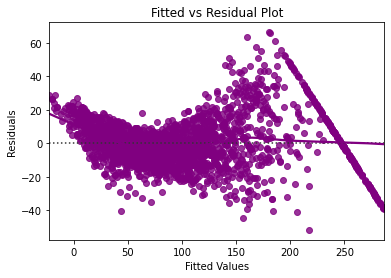

```python
# plotting fitted vs residuals
sns.residplot(
    data=df_pred, x="Fitted Values", y="Residuals", color="purple", lowess=True
)
plt.xlabel("Fitted Values")
plt.ylabel("Residuals")
plt.title("Fitted vs Residual Plot")
plt.show()
```

#### Testing for Normality

- Use a Q-Q plot of residuals. If the residuals follow a normal distribution, they will make a straight line, otherwise it is not a normal distribution.
  - Null Hypothesis: Residuals are normally distributed
  - Alternate Hypothesis: Residuals are not normally distributed

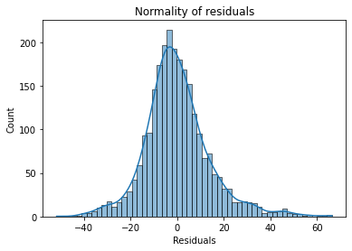

```python
sns.histplot(data=df_pred, x="Residuals", kde=True)
plt.title("Normality of residuals")
plt.show()
```

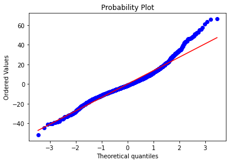

```python
# Q-Q plot
import pylab
import scipy.stats as stats

stats.probplot(df_pred["Residuals"], dist="norm", plot=pylab)
plt.show()
```

- The residuals more or less follow a straight line, except the tails where the extreme outliers are present

```python
# Shapiro-Wilk test
stats.shapiro(df_pred["Residuals"])
```

```
ShapiroResult(statistic=0.962329089641571, pvalue=5.260188610962256e-25)
```

### Testing for Homoscedasticity

- We will test to see if the residual variance is symmetrically distributed across the regression line.
- If the variance is unequal across the residuals, then the data is heteroscedastic.

```python
# goldfeldquandt test
import statsmodels.stats.api as sms
from statsmodels.compat import lzip

name = ["F statistic", "p-value"]
test = sms.het_goldfeldquandt(df_pred["Residuals"], x_train1)
lzip(name, test)
```

```
[('F statistic', 1.034581056281413), ('p-value', 0.2779043679249576)]
```

- p-value is >0.05 so the residuals are homoscedastic

```python
# predictions on the test set
pred = olsmod0.predict(x_test1)

df_pred_test = pd.DataFrame({"Actual": y_test, "Predicted": pred})
df_pred_test.sample(10, random_state=1)
```

|  | Actual | Predicted |
| --- | --- | --- |
| 2098 | 30.520 | 21.819 |
| 278 | 195.670 | 190.084 |
| 26 | 247.192 | 222.895 |
| 2910 | 89.970 | 91.370 |
| 2631 | 69.200 | 64.690 |
| 1582 | 89.580 | 107.294 |
| 2110 | 247.192 | 263.912 |
| 3160 | 65.340 | 67.927 |
| 2817 | 115.770 | 106.830 |
| 549 | 39.290 | 47.758 |

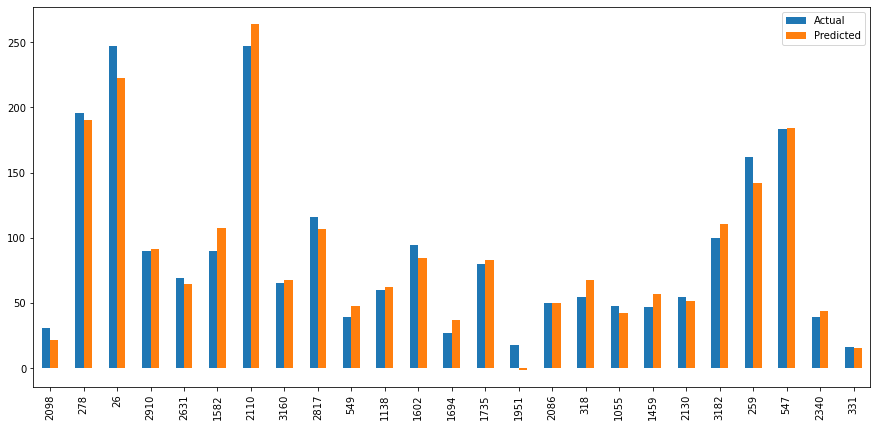

```python
df1 = df_pred_test.sample(25, random_state=1)
df1.plot(kind="bar", figsize=(15, 7))
plt.show()
```

### Observations

- The model predicst fairly close to the actual values given the outlier nature of pricing of cell phones and the sample size.

## Final Model Summary

```python
# checking model performance on train set (seen 70% data)
print("Training Performance\n")
olsmod0_train_perf = model_performance_regression(olsmod0, x_train1, y_train)
olsmod0_train_perf
```

```
Training Performance
```

|  | RMSE | MAE | R-squared | Adj. R-squared | MAPE |
| --- | --- | --- | --- | --- | --- |
| 0 | 13.960 | 10.222 | 0.955 | 0.954 | 18.489 |

```python
# checking model performance on test set (seen 30% data)
print("Test Performance\n")
olsmod0_test_perf = model_performance_regression(olsmod0, x_test1, y_test)
olsmod0_test_perf
```

```
Test Performance
```

|  | RMSE | MAE | R-squared | Adj. R-squared | MAPE |
| --- | --- | --- | --- | --- | --- |
| 0 | 13.745 | 10.171 | 0.957 | 0.955 | 16.418 |

```python
# training performance comparison

models_train_comp_df = pd.concat(
    [linearregression_train_perf.T, olsmod0_train_perf.T],
    axis=1,
)

models_train_comp_df.columns = [
    "Linear Regression sklearn",
    "Linear Regression statsmodels",
]

print("Training performance comparison:")
models_train_comp_df
```

```
Training performance comparison:
```

|  | Linear Regression sklearn | Linear Regression statsmodels |
| --- | --- | --- |
| RMSE | 13.745 | 13.960 |
| MAE | 10.171 | 10.222 |
| R-squared | 0.957 | 0.955 |
| Adj. R-squared | 0.955 | 0.954 |
| MAPE | 16.418 | 18.489 |

```python
# Final StatsModel
olsmodel_final = sm.OLS(y_train, x_train1).fit()
print(olsmodel_final.summary())
```

```
                            OLS Regression Results
==============================================================================
Dep. Variable:             used_price   R-squared:                       0.955
Model:                            OLS   Adj. R-squared:                  0.954
Method:                 Least Squares   F-statistic:                     1110.
Date:                Tue, 17 Aug 2021   Prob (F-statistic):               0.00
Time:                        09:52:46   Log-Likelihood:                -10134.
No. Observations:                2499   AIC:                         2.036e+04
Df Residuals:                    2451   BIC:                         2.064e+04
Df Model:                          47
Covariance Type:            nonrobust
=========================================================================================
                            coef    std err          t      P>|t|      [0.025      0.975]
-----------------------------------------------------------------------------------------
const                   557.4842    553.062      1.008      0.314    -527.032    1642.000
screen_size               0.2077      0.127      1.633      0.103      -0.042       0.457
main_camera_mp           -0.2743      0.092     -2.984      0.003      -0.455      -0.094
selfie_camera_mp          0.8381      0.105      8.008      0.000       0.633       1.043
int_memory                0.0859      0.011      7.998      0.000       0.065       0.107
battery                   0.0001      0.000      0.313      0.754      -0.001       0.001
weight                   -0.0123      0.012     -0.989      0.323      -0.037       0.012
release_year             -0.2459      0.274     -0.896      0.370      -0.784       0.292
days_used                -0.0846      0.002    -46.373      0.000      -0.088      -0.081
new_price                 0.3845      0.003    111.668      0.000       0.378       0.391
brand_name_Alcatel        0.1804      2.956      0.061      0.951      -5.616       5.977
brand_name_Apple         23.2431     10.523      2.209      0.027       2.609      43.878
brand_name_Asus           0.5894      2.945      0.200      0.841      -5.185       6.364
brand_name_BlackBerry     6.6973      4.641      1.443      0.149      -2.404      15.798
brand_name_Celkon        -0.7165      3.855     -0.186      0.853      -8.277       6.844
brand_name_Coolpad        6.6154      4.571      1.447      0.148      -2.347      15.578
brand_name_Gionee        -5.2878      3.405     -1.553      0.121     -11.964       1.389
brand_name_Google        12.2293      4.860      2.516      0.012       2.699      21.760
brand_name_HTC           -0.6396      3.000     -0.213      0.831      -6.523       5.244
brand_name_Honor          2.0717      3.021      0.686      0.493      -3.852       7.995
brand_name_Huawei         0.9722      2.762      0.352      0.725      -4.444       6.388
brand_name_Infinix      -14.9025      6.366     -2.341      0.019     -27.385      -2.420
brand_name_Karbonn       -1.3573      3.880     -0.350      0.726      -8.965       6.251
brand_name_LG             1.7448      2.778      0.628      0.530      -3.703       7.193
brand_name_Lava          -1.3213      3.711     -0.356      0.722      -8.598       5.956
brand_name_Lenovo        -1.7203      2.849     -0.604      0.546      -7.308       3.867
```

[output cut: 18 more lines]

```
os_Windows                2.5289      2.718      0.930      0.352      -2.801       7.859
os_iOS                  -15.8083     10.454     -1.512      0.131     -36.308       4.691
4g_yes                   -2.8843      0.914     -3.155      0.002      -4.677      -1.092
5g_yes                    2.1229      1.723      1.232      0.218      -1.256       5.502
==============================================================================
Omnibus:                      288.376   Durbin-Watson:                   1.983
Prob(Omnibus):                  0.000   Jarque-Bera (JB):              655.279
Skew:                           0.685   Prob(JB):                    5.10e-143
Kurtosis:                       5.102   Cond. No.                     7.53e+06
==============================================================================

Notes:
[1] Standard Errors assume that the covariance matrix of the errors is correctly specified.
[2] The condition number is large, 7.53e+06. This might indicate that there are
strong multicollinearity or other numerical problems.
```

## Actionable Insights and Recommendations

- Our model predicts 95% of the variation in the data, which is pretty good
- The train and test RMSE and MAE are very comparable, so the model is not suffering from overfitting.
- Our model can predict within 16% of the used_price.
- Our linear model comparison between methods is very close.

## Going Forward

- Going forward it may behoove the model to be adjusted via dropping more columns/data to attempt to get a better and lower MAPE value to increase the inferential capability of the model.
- Adjusting the model further by aggressively reducing any mutlicollinearity could offer a better predictive model at the potential cost of a robust model as most of the impactful variables are brands of phones.
- ReCell will have to analyze the current model and determine if it fits their current needs, and then adjust the model to increase it predictive powers.